# Chapter 1. 전처리

## 문제 0. 기본세팅

패키지를 plyr, tidyverse, data.table 순으로 부른 후, setwd로 ‘data.csv’가 있는 폴더로 경로를 설정하고, fread로 ‘data.csv’를 불러오세요.

```python
import numpy as np
import pandas as pd
import os
os.listdir()
import warnings
warnings.filterwarnings("ignore")
```

```python
data = pd.read_csv('data.csv', encoding='cp949')
```

## 문제1. 데이터 확인하기

str으로 데이터의 구성을 살펴보고, 각 열마다 NA 개수와 unique 값 및 개수를 확인해 보세 요. (colSums, unique, length 이용 시 편리)

```python
data.info()
```

```
<class 'pandas.core.frame.DataFrame'>
RangeIndex: 5165 entries, 0 to 5164
Data columns (total 8 columns):
 #   Column          Non-Null Count  Dtype
---  ------          --------------  -----
 0   patient_id      5165 non-null   int64
 1   sex             4043 non-null   object
 2   age             3785 non-null   object
 3   country         5165 non-null   object
 4   province        5165 non-null   object
 5   city            5071 non-null   object
 6   confirmed_date  5162 non-null   object
 7   state           5165 non-null   object
dtypes: int64(1), object(7)
memory usage: 322.9+ KB
```

```python
data.isnull().sum()
```

```
patient_id           0
sex               1122
age               1380
country              0
province             0
city                94
confirmed_date       3
state                0
dtype: int64
```

```python
col = data.columns.to_list()
for i in col:
    print("===================",i,"================")
    print(data[i].unique())
    print(len(data[i].unique()))
```

```
=================== patient_id ================
[1000000001 1000000002 1000000003 ... 7000000017 7000000018 7000000019]
5164
=================== sex ================
['male' 'female' nan]
3
=================== age ================
['50s' '30s' '20s' '60s' '80s' '70s' '40s' '10s' '90s' '0s' nan '100s']
12
=================== country ================
['Korea' 'China' 'United States' 'France' 'Thailand' 'Canada' 'India'
 'Switzerland' 'Germany' 'Indonesia' 'Vietnam' 'Foreign' 'Mongolia'
 'United Kingdom' 'Spain' 'Bangladesh']
16
=================== province ================
['서울' '부산' '대구' '광주' '인천' '대전' '경기도' '세종' '울산' '강원도' '충청북도' '충청남도' '전라북도'
 '전라남도' '경상북도' '경상남도' '제주도']
17
=================== city ================
['강서구' '중랑구' '종로구' '마포구' '성북구' '기타' '송파구' '서대문구' '성동구' '서초구' '구로구' '강동구'
 '은평구' '금천구' '관악구' '노원구' '동구 구' '강남구' '양천구' '광진구' '동대문구' '영등포구' '도봉구'
 '용산구' '강북구' '중구' '동래구' '해운대구' '연제구' nan '북구' '남구' '서구' '금정구' '사하구' '수영구'
 '사상구' '부산진구' '기장' '동구' '달서구' '달성' '수성구' '달성군' '경산시' '상곡 동' '이천동' '영천시'
 '부평구' '미추홀 구' '연수구' '계양구' '남동구' '강화군' '유성구' '대덕구' '수원시' '세종' '울주' '고양시'
 '평택시' '부천시' '구리시' '시흥시' '김포시' '이천시' '포천시' '안양시' '용인시' '파주시' '남양주시' '성남시'
 '과천시' '광명시' '화성시' '오산시' '군포시' '의왕시' '안산시' '광주' '안성시' '의정부시' '하남시' '동두천시'
 '양주시' '가평' '양평시' '수원' '구리' '강릉시' '삼척시' '속초' '원주시' '춘천시' '태백시' '인제' '횡성'
 '영월' '철원' '증평' '청주시' '음성군' '충주시' '괴산' '단양' '진천' '옥천' '계룡시' '천안시' '아산시'
 '서산시' '홍성' '태안' '부여군' '서천' '논산시' '공주시' '군산시' '김제시' '전주시' '익산시' '장수' '순천시'
 '여수시' '광양시' '화순' '무안' '목포시' '경주시' '고령' '구미시' '군위' '김천시' '문경시' '봉화' '상주시'
 '성주' '안동시' '영덕' '영양' '영주시' '예천' '의성' '청도' '청송' '칠곡' '포항시' '합천' '진주시'
 '창원시' '양산' '거제' '함양' '고성' '김해시' '남해' '거창' '창녕' '밀양시' '하만' '산청' '사천시'
 '제주도']
163
=================== confirmed_date ================
['2020-01-23' '2020-01-30' '2020-01-31' '2020-02-02' '2020-02-05'
 '2020-02-06' '2020-02-07' '2020-02-16' '2020-02-19' '2020-02-20'
 '2020-02-21' '2020-02-22' '2020-02-23' '2020-02-26' '2020-02-24'
 '2020-02-25' '2020-02-27' '2020-02-28' '2020-02-29' '2020-03-01'
 '2020-03-02' '2020-03-04' '2020-03-05' '2020-03-06' '2020-03-07'
```

[output cut: 14 more lines]

```
 '2020-05-27' '2020-05-28' '2020-05-29' '2020-05-30' '2020-05-31'
 '2020-06-01' '2020-06-02' '2020-06-03' '2020-06-04' '2020-06-05'
 '2020-06-06' '2020-06-07' '2020-06-08' '2020-06-09' '2020-06-10'
 '2020-06-11' '2020-06-12' '2020-06-13' '2020-06-14' '2020-06-15'
 '2020-06-16' '2020-06-17' '2020-06-18' '2020-06-19' '2020-06-20'
 '2020-06-21' '2020-06-22' '2020-06-23' '2020-06-24' '2020-06-25'
 '2020-06-26' '2020-06-27' '2020-06-28' '2020-06-29' '2020-03-03'
 '2020-04-22' '2020-04-23' '2020-04-25' '2020-05-07' '2020-02-18'
 '2020-04-28' '2020-04-26' '2020-02-03' '2020-01-20' '2020-05-03'
 '2020-06-30' '2020-05-06' '2020-01-26' '2020-01-27' '2020-02-01'
 '2020-02-09' '2020-02-10' '2020-04-29' nan]
149
=================== state ================
['released' 'deceased' 'isolated']
3
```

## 문제 2-1

NA가 있는 행을 삭제하세요.

```python
data1 = data.dropna()
```

```python
data1.isnull().sum()
```

```
patient_id        0
sex               0
age               0
country           0
province          0
city              0
confirmed_date    0
state             0
dtype: int64
```

## 문제 2-2

빈 문자열(“”)이 있는 행을 삭제하고, 각 열마다 NA 개수와 unique 값 및 개수를 다시 확인해 보세요. (which, 논리연산자 이용 시 편리)

```python
data.isin([""]).any()
```

```
patient_id        False
sex               False
age               False
country           False
province          False
city              False
confirmed_date    False
state             False
dtype: bool
```

```python
data1.isin([""]).any()
```

```
patient_id        False
sex               False
age               False
country           False
province          False
city              False
confirmed_date    False
state             False
dtype: bool
```

```python
col = data1.columns.to_list()
for i in col:
    print("===================",i,"================")
    print(data1[i].unique())
    print(len(data1[i].unique()))
```

```
=================== patient_id ================
[1000000001 1000000002 1000000003 ... 7000000013 7000000014 7000000015]
3689
=================== sex ================
['male' 'female']
2
=================== age ================
['50s' '30s' '20s' '60s' '80s' '70s' '40s' '10s' '90s' '0s' '100s']
11
=================== country ================
['Korea' 'China' 'United States' 'France' 'Thailand' 'Canada'
 'Switzerland' 'Germany' 'Indonesia' 'Vietnam' 'Foreign' 'Mongolia'
 'United Kingdom' 'Spain' 'Bangladesh']
15
=================== province ================
['서울' '부산' '대구' '인천' '대전' '경기도' '세종' '울산' '강원도' '충청북도' '충청남도' '전라북도'
 '전라남도' '경상북도' '경상남도' '제주도']
16
=================== city ================
['강서구' '중랑구' '종로구' '마포구' '성북구' '기타' '송파구' '서대문구' '성동구' '서초구' '구로구' '강동구'
 '은평구' '금천구' '관악구' '노원구' '동구 구' '강남구' '양천구' '광진구' '동대문구' '영등포구' '도봉구'
 '용산구' '강북구' '중구' '동래구' '해운대구' '연제구' '북구' '남구' '서구' '금정구' '사하구' '수영구'
 '사상구' '부산진구' '기장' '동구' '달서구' '달성' '수성구' '달성군' '경산시' '상곡 동' '이천동' '영천시'
 '부평구' '미추홀 구' '연수구' '계양구' '남동구' '강화군' '유성구' '대덕구' '수원시' '세종' '울주' '고양시'
 '평택시' '부천시' '구리시' '시흥시' '김포시' '이천시' '포천시' '안양시' '용인시' '파주시' '남양주시' '성남시'
 '과천시' '광명시' '화성시' '오산시' '군포시' '의왕시' '안산시' '광주' '안성시' '의정부시' '하남시' '동두천시'
 '양주시' '가평' '양평시' '강릉시' '삼척시' '속초' '원주시' '춘천시' '태백시' '인제' '횡성' '영월' '철원'
 '증평' '청주시' '음성군' '충주시' '괴산' '단양' '진천' '옥천' '계룡시' '천안시' '아산시' '서산시' '홍성'
 '태안' '부여군' '서천' '논산시' '공주시' '군산시' '김제시' '전주시' '익산시' '장수' '순천시' '여수시'
 '광양시' '화순' '무안' '목포시' '경주시' '고령' '구미시' '김천시' '문경시' '봉화' '상주시' '성주' '안동시'
 '영양' '영주시' '예천' '의성' '청도' '청송' '칠곡' '포항시' '합천' '진주시' '창원시' '양산' '거제' '함양'
 '고성' '김해시' '남해' '거창' '창녕' '밀양시' '하만' '산청' '사천시' '제주도']
158
=================== confirmed_date ================
['2020-01-23' '2020-01-30' '2020-01-31' '2020-02-02' '2020-02-05'
 '2020-02-06' '2020-02-07' '2020-02-16' '2020-02-19' '2020-02-20'
 '2020-02-21' '2020-02-22' '2020-02-23' '2020-02-26' '2020-02-24'
 '2020-02-25' '2020-02-27' '2020-02-28' '2020-02-29' '2020-03-01'
 '2020-03-02' '2020-03-04' '2020-03-05' '2020-03-06' '2020-03-07'
 '2020-03-08' '2020-03-09' '2020-03-10' '2020-03-11' '2020-03-12'
```

[output cut: 12 more lines]

```
 '2020-06-06' '2020-06-04' '2020-05-31' '2020-05-30' '2020-05-26'
 '2020-06-16' '2020-06-17' '2020-05-22' '2020-05-19' '2020-05-17'
 '2020-05-16' '2020-05-15' '2020-05-14' '2020-05-13' '2020-05-09'
 '2020-05-02' '2020-04-28' '2020-04-27' '2020-06-22' '2020-06-21'
 '2020-04-26' '2020-04-24' '2020-04-20' '2020-04-19' '2020-06-25'
 '2020-06-28' '2020-01-20' '2020-04-10' '2020-04-12' '2020-04-13'
 '2020-04-16' '2020-04-17' '2020-04-08' '2020-05-05' '2020-05-06'
 '2020-06-18' '2020-06-24' '2020-06-26' '2020-06-29' '2020-06-30'
 '2020-04-11' '2020-05-03' '2020-05-21' '2020-01-26' '2020-01-27'
 '2020-02-01' '2020-02-09' '2020-02-10' '2020-04-29' '2020-04-30'
 '2020-05-23' '2020-06-05' '2020-06-09' '2020-06-08' '2020-06-14']
145
=================== state ================
['released' 'deceased' 'isolated']
3
```

## 문제 3

country가 ‘Korea’인 행만 남긴 다음, country 열을 제거하세요.

```python
data_Kor = data1[data1['country']=='Korea']
data_Kor.drop(columns=['country'], inplace=True)
```

## 문제 4

province 변수 내 ‘서울, 부산, 대구, 인천, 대전, 세종, 울산, 제주도’ 값을 다음과 같이 바꾸세요.

서울 -> 서울특별시, 부산 -> 부산광역시, 대구 -> 대구광역시, 인천 -> 인천광역시, 대전 -> 대전광역시,세종 -> 세종특별자치시, 울산 -> 울산광역시, 제주도 -> 제주특별자치도

```python
data_Kor['province'].replace({"서울": "서울특별시", "부산": "부산광역시", "대구": "대구광역시",
                              "인천": "인천광역시", "대전": "대전광역시", "세종": "세종특별자치시",
                             "울산": "울산광역시", "제주도": "제주특별자치도"}, inplace=True)
```

```python
data_Kor.head()
```

|  | patient_id | sex | age | province | city | confirmed_date | state |
| --- | --- | --- | --- | --- | --- | --- | --- |
| 0 | 1000000001 | male | 50s | 서울특별시 | 강서구 | 2020-01-23 | released |
| 1 | 1000000002 | male | 30s | 서울특별시 | 중랑구 | 2020-01-30 | released |
| 2 | 1000000003 | male | 50s | 서울특별시 | 종로구 | 2020-01-30 | released |
| 3 | 1000000004 | male | 20s | 서울특별시 | 마포구 | 2020-01-30 | released |
| 4 | 1000000005 | female | 20s | 서울특별시 | 성북구 | 2020-01-31 | released |

## 문제 5

confirmed_date를 날짜 자료형(Date)으로 바꾸세요.

```python
data_Kor["confirmed_date"] = pd.to_datetime(data_Kor["confirmed_date"])
```

```python
data_Kor.info()
```

```
<class 'pandas.core.frame.DataFrame'>
Int64Index: 3653 entries, 0 to 5160
Data columns (total 7 columns):
 #   Column          Non-Null Count  Dtype
---  ------          --------------  -----
 0   patient_id      3653 non-null   int64
 1   sex             3653 non-null   object
 2   age             3653 non-null   object
 3   province        3653 non-null   object
 4   city            3653 non-null   object
 5   confirmed_date  3653 non-null   datetime64[ns]
 6   state           3653 non-null   object
dtypes: datetime64[ns](1), int64(1), object(5)
memory usage: 228.3+ KB
```

## 문제 6

확진날짜(confirmed_date) 별 확진자 수에 대한 파생변수를 만드세요. (파생변수 이름 : confirmed_number)

```python
confirmed_number = data_Kor['confirmed_date'].value_counts()
```

```python
data_Kor['confirmed_number'] = data_Kor.apply(lambda x:confirmed_number[x["confirmed_date"]], axis=1)
```

## 문제 7

확진날짜(confirmed_date)의 주말 여부에 대한 파생변수를 만드세요. (파생변수 이름 : wday)

```python
pd.__version__
```

```
'1.2.3'
```

```python
wday = data_Kor['confirmed_date'].dt.weekday
data_Kor['wday'] = wday.apply(lambda x: "주말" if x ==5 or x==6 else "주중")
```

## 문제 8

나이대 별 일별 확진자 수에 대한 summary를 확인해 보세요. (예 : 10대의 날짜별 확진자 수의 분포)

```python
ages = sorted(data_Kor['age'].unique().tolist())
age_df=pd.DataFrame(columns=['mean','std','min','25%','50%','75%','max','count'])
age_group = data_Kor.groupby('age')['confirmed_date'].value_counts()
for i in ages:
    age_df = age_df.append(age_group[i].describe().rename(i))
```

```python
age_df
```

|  | mean | std | min | 25% | 50% | 75% | max | count |
| --- | --- | --- | --- | --- | --- | --- | --- | --- |
| 0s | 1.488372 | 0.735886 | 1.0 | 1.0 | 1.0 | 2.00 | 3.0 | 43.0 |
| 100s | 1.000000 | NaN | 1.0 | 1.0 | 1.0 | 1.00 | 1.0 | 1.0 |
| 10s | 2.276316 | 1.604981 | 1.0 | 1.0 | 2.0 | 3.00 | 8.0 | 76.0 |
| 20s | 7.525862 | 9.026975 | 1.0 | 1.0 | 3.5 | 11.00 | 43.0 | 116.0 |
| 30s | 5.051020 | 4.475299 | 1.0 | 2.0 | 3.0 | 8.00 | 17.0 | 98.0 |
| 40s | 4.931373 | 5.877057 | 1.0 | 1.0 | 2.0 | 6.00 | 33.0 | 102.0 |
| 50s | 6.112150 | 6.518952 | 1.0 | 1.0 | 3.0 | 9.00 | 31.0 | 107.0 |
| 60s | 4.721649 | 4.251819 | 1.0 | 1.0 | 3.0 | 7.00 | 22.0 | 97.0 |
| 70s | 2.907895 | 2.634022 | 1.0 | 1.0 | 2.0 | 3.25 | 13.0 | 76.0 |
| 80s | 3.018519 | 3.794190 | 1.0 | 1.0 | 2.0 | 3.75 | 24.0 | 54.0 |
| 90s | 2.285714 | 3.333809 | 1.0 | 1.0 | 1.0 | 2.00 | 16.0 | 21.0 |

# Chapter 2. 시각화

## 문제 1 Line Plot

confirmed_date와 confirmed_number 변수를 이용하여 확진자수 추이 그래프를 그리고, 최대 확 진자에 대한 정보도 표시하세요. (적절한 함수를 이용하여 #대신 정확한 날짜 및 수를 쓸 것 , 색:navy, lightblue, 제목:bold체)

```python
import matplotlib.pyplot as plt
import seaborn as sns
import matplotlib as mpl
sns.set_theme(style='white',palette='pastel')

fontpath = 'C:/Windows/Fonts/NanumBarunGothicBold.ttf'
font_name = mpl.font_manager.FontProperties(fname=fontpath, size=10).get_name()
plt.rc('font', family=font_name)
```

```
Text(2020-03-05 00:00:00, 143, '20-03-05 (143명)')
```

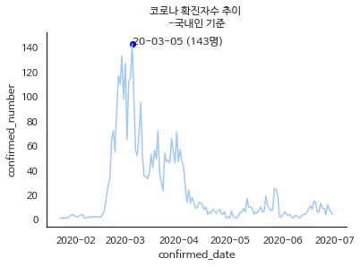

```python
ax = sns.lineplot(x = confirmed_number.index, y = confirmed_number.values)
ax.set_title("코로나 확진자수 추이 \n-국내인 기준")
ax.set_xlabel('confirmed_date')
ax.set_ylabel('confirmed_number')
ax.spines['top'].set_visible(False)
ax.spines['right'].set_visible(False)
x, y= confirmed_number.index[0], confirmed_number.values[0]
ax.scatter(x,y,c='blue')
ax.annotate(f'{x:%y-%m-%d} ({y}명)', xy=(x,y))
```

## 문제 1-2 Line Plot

province 별 확진자 수 추이 그래프를 그리세요

```python
group = data_Kor.groupby('province')['confirmed_date'].value_counts()
```

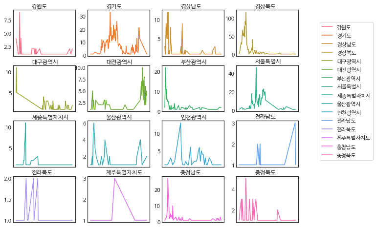

```python
clr = sns.color_palette("husl", 16)
prov = sorted(data_Kor["province"].unique().tolist())
fig = plt.figure(figsize=(12,8))
legend = {}
for i in range(4):
    for j in range(4):
        area = i*4 + j + 1
        temp_area = group.loc[prov[area-1]]
        ax = fig.add_subplot(4,4,area)
        ax.text(0.3,1.05, prov[area-1], transform=ax.transAxes)
        sns.lineplot(x=temp_area.index, y=temp_area.values,label=prov[area-1], c=clr[area-1])
        ax.set_xticklabels([])
        ax.tick_params(axis='y', length=0)
        ax.set_xlabel('')
        handle, label = ax.get_legend_handles_labels()
        legend[label[0]] = handle[0]
        ax.legend([],[], frameon=False)
handles = legend.values()
labels = legend.keys()
fig.legend(handles=handles, labels=labels,loc=(0.85,0.3))
fig.subplots_adjust(right=0.8)
```

```python
a = {}
a['s'] = 1
a
```

```
{'s': 1}
```

# 문제 2 Bar Plot

지역별 확진자 수를 state(확진자 상황) 그룹 별로 나누어 그래프를 그리세요

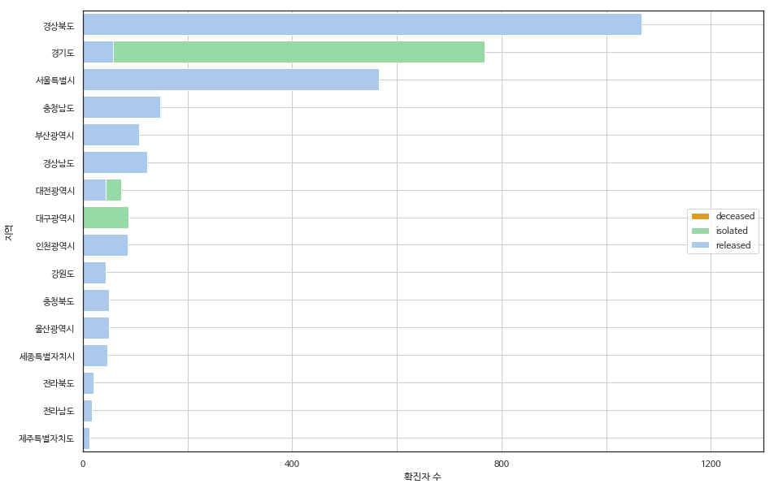

```python
f, ax = plt.subplots(figsize=(15,10))
g = data_Kor.groupby(['province','state']).count()['confirmed_number']
group = g.unstack()

dic = {}
for i in prov:
    dic[i] = g[i].sum()
order = sorted(dic, key=lambda x: dic[x], reverse=True)

sns.barplot(x='deceased', y=group.index, data=group,label='deceased', color='orange', order=order)
sns.barplot(x='isolated', y=group.index, data=group,label='isolated', color='g', order=order)
sns.barplot(x='released', y=group.index, data=group,label='released', color='b', order=order)
ax.set_xlim(0,1300)
ax.grid(axis='y', zorder=1)
ax.grid(axis='x', zorder=200)
ax.set_xticklabels(['0','','400','','800','','1200'])
ax.set_xlabel("확진자 수")
ax.set_ylabel("지역")
ax.legend(loc=5)
```

## 문제 3 Box Plot

나이대별 일별 확진자 수 box plot을 그리세요

```python
a = pd.DataFrame(age_group)
```

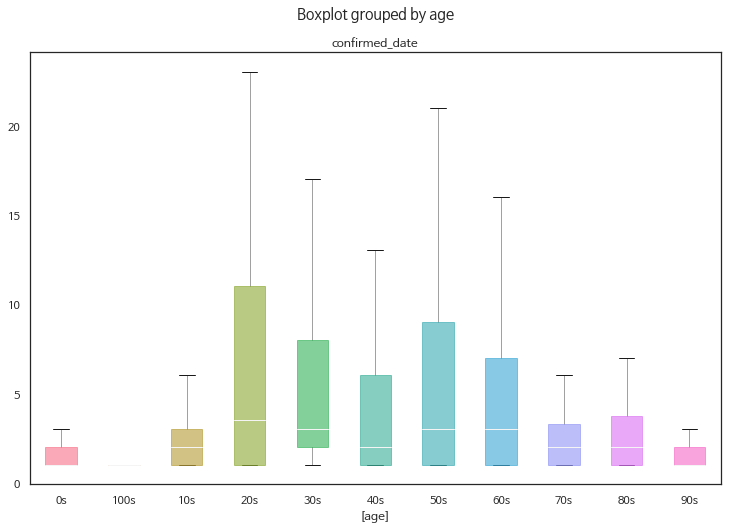

```python
clr = sns.color_palette("husl", 11)
fig, ax = plt.subplots(figsize=(12,8))
box = a.boxplot(by='age', ax=ax, grid=False, showfliers=False, return_type='both', patch_artist=True)


for row_key, (ax,row) in box.iteritems():
    for i, box in enumerate(row['boxes']):
        box.set_color(clr[i])
        box.set_alpha(0.6)
```

## 문제 3-2

나이대별 일별 확진자 수에 대한 일원분산분석(one-way ANOVA)을 실시하여 해석해 보세요

요건 포기하겠습니다 ...ㅠ

## 문제 4 Map

geopandas 설치 시작한지 16시간째입니다...

# Chapter 3. 모델링_회귀분석

## 문제 1.

아래처럼 상관계수 플랏을 만들고 간단히 해석해 보세요.

```python
from sklearn.datasets import load_boston
data = load_boston()
df = pd.DataFrame(data.data, columns=data.feature_names)
df['MEDV'] = data.target
```

```python
df.corr()
```

|  | CRIM | ZN | INDUS | CHAS | NOX | RM | AGE | DIS | RAD | TAX | PTRATIO | B | LSTAT | MEDV |
| --- | --- | --- | --- | --- | --- | --- | --- | --- | --- | --- | --- | --- | --- | --- |
| CRIM | 1.000000 | -0.200469 | 0.406583 | -0.055892 | 0.420972 | -0.219247 | 0.352734 | -0.379670 | 0.625505 | 0.582764 | 0.289946 | -0.385064 | 0.455621 | -0.388305 |
| ZN | -0.200469 | 1.000000 | -0.533828 | -0.042697 | -0.516604 | 0.311991 | -0.569537 | 0.664408 | -0.311948 | -0.314563 | -0.391679 | 0.175520 | -0.412995 | 0.360445 |
| INDUS | 0.406583 | -0.533828 | 1.000000 | 0.062938 | 0.763651 | -0.391676 | 0.644779 | -0.708027 | 0.595129 | 0.720760 | 0.383248 | -0.356977 | 0.603800 | -0.483725 |
| CHAS | -0.055892 | -0.042697 | 0.062938 | 1.000000 | 0.091203 | 0.091251 | 0.086518 | -0.099176 | -0.007368 | -0.035587 | -0.121515 | 0.048788 | -0.053929 | 0.175260 |
| NOX | 0.420972 | -0.516604 | 0.763651 | 0.091203 | 1.000000 | -0.302188 | 0.731470 | -0.769230 | 0.611441 | 0.668023 | 0.188933 | -0.380051 | 0.590879 | -0.427321 |
| RM | -0.219247 | 0.311991 | -0.391676 | 0.091251 | -0.302188 | 1.000000 | -0.240265 | 0.205246 | -0.209847 | -0.292048 | -0.355501 | 0.128069 | -0.613808 | 0.695360 |
| AGE | 0.352734 | -0.569537 | 0.644779 | 0.086518 | 0.731470 | -0.240265 | 1.000000 | -0.747881 | 0.456022 | 0.506456 | 0.261515 | -0.273534 | 0.602339 | -0.376955 |
| DIS | -0.379670 | 0.664408 | -0.708027 | -0.099176 | -0.769230 | 0.205246 | -0.747881 | 1.000000 | -0.494588 | -0.534432 | -0.232471 | 0.291512 | -0.496996 | 0.249929 |
| RAD | 0.625505 | -0.311948 | 0.595129 | -0.007368 | 0.611441 | -0.209847 | 0.456022 | -0.494588 | 1.000000 | 0.910228 | 0.464741 | -0.444413 | 0.488676 | -0.381626 |
| TAX | 0.582764 | -0.314563 | 0.720760 | -0.035587 | 0.668023 | -0.292048 | 0.506456 | -0.534432 | 0.910228 | 1.000000 | 0.460853 | -0.441808 | 0.543993 | -0.468536 |
| PTRATIO | 0.289946 | -0.391679 | 0.383248 | -0.121515 | 0.188933 | -0.355501 | 0.261515 | -0.232471 | 0.464741 | 0.460853 | 1.000000 | -0.177383 | 0.374044 | -0.507787 |
| B | -0.385064 | 0.175520 | -0.356977 | 0.048788 | -0.380051 | 0.128069 | -0.273534 | 0.291512 | -0.444413 | -0.441808 | -0.177383 | 1.000000 | -0.366087 | 0.333461 |
| LSTAT | 0.455621 | -0.412995 | 0.603800 | -0.053929 | 0.590879 | -0.613808 | 0.602339 | -0.496996 | 0.488676 | 0.543993 | 0.374044 | -0.366087 | 1.000000 | -0.737663 |
| MEDV | -0.388305 | 0.360445 | -0.483725 | 0.175260 | -0.427321 | 0.695360 | -0.376955 | 0.249929 | -0.381626 | -0.468536 | -0.507787 | 0.333461 | -0.737663 | 1.000000 |

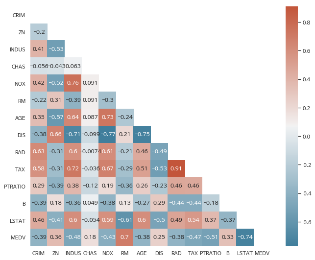

```python
f, ax =plt.subplots(figsize=(11,9))
corr = df.corr()
mask =np.triu(np.ones_like(corr, dtype=bool))
cmap = sns.diverging_palette(230, 20, as_cmap=True)
ax = sns.heatmap(corr, annot=True,mask=mask,cmap=cmap)
```

```python
#print(data.DESCR)
```

## 문제 2

아래와 같이 종속변수로 사용할 medv와 이외 변수 간의 관계 파악을 위한 scatterplot 및 회귀 추세선을 그려보세요. (gather 이용 시 편리, 색 : lightblue)

```python
a = df.columns.tolist()
a.remove('MEDV')
```

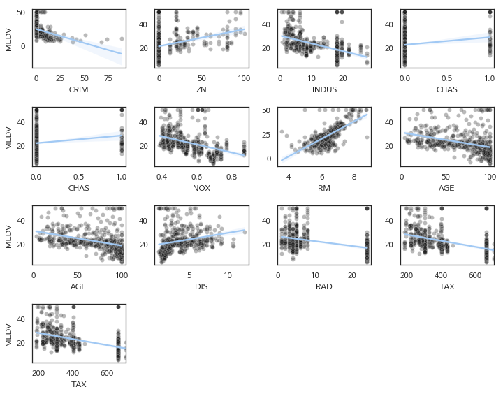

```python
cols = df.columns.tolist()
cols.remove('MEDV')
fig, ax = plt.subplots(ncols=4, nrows=4, figsize=(12,8))
for i in range(4):
    for j in range(4):
        if i*3+j <= 13:
            sns.scatterplot(x=cols[i*3+j], y='MEDV', data=df,color='k', ax=ax[i][j], alpha=0.3)
            sns.regplot(x=cols[i*3+j], y="MEDV", data=df,scatter=False, ax=ax[i][j])
            if j!=0:
                ax[i][j].set_ylabel('')

ax[3][1].set_visible(False)
ax[3][2].set_visible(False)
ax[3][3].set_visible(False)
fig.tight_layout(rect=[0,0,0.85,1])
```